# Modeling Process Quality

# 1. Describing Variability

## Stem-and-Leaf Plot

- One of the most useful graphica techniques for summarizing and presenting data.

### Process

- Assuming each data consists of at least two digits.
- divide each number into two parts:
  - stem, consisting of one or more of the leading digits
  - leaf, consisting of the remaining digits
- choose relatively few stems in comparison with the number of observations (between 5 and 20 stems)
- list the chosen stems along the left-hand margin of the display
- list beside each stem all leaves corresponding to the observed data values according to the order in which they are encountered in the data set.

```r
days <- c(48,41,35,36,37,26,36,46,35,47,35,34,36,42,43,36,56,32,46,30,37,43,17,26,28,27,45,33,22,27,16,22,33,30,24,23,22,30,31,17)
stem(days)
```

```
  The decimal point is 1 digit(s) to the right of the |

  1 | 677
  2 | 22234
  2 | 66778
  3 | 00012334
  3 | 555666677
  4 | 1233
  4 | 56678
  5 |
  5 | 6
```

## Time Series Plot (Run Chart)

- A plot of data values versus time.
- Called a marginal plot if a histogram/dot plot is attached to the margin of the chart.

```r
###################################
# First Attempt, ggExtra approach
###################################
library(ggplot2)
library(ggExtra)
library(grid)
times <- c(1:40)
df <- data.frame(times, days)
p <- ggplot(df,aes(times,days))+ geom_point() +theme_classic()
mp <- ggMarginal(p,type="histogram",margins="y")
grid.newpage()
```

```r
grid.draw(mp)
##################################################
# Second Attemp, Layout approach--preferable way
##################################################
new_layout <- layout(matrix(c(1,2),nrow=1,ncol=2),widths=c(5,1),heights=c(5,5),TRUE)
```

[output not shown]

```r
par(mar=c(5,4,2,0))
```

```r
plot(df,xlab="Times",ylab="Days",main="Marginal Plot")
par(mar=c(5,0,2,1))
```

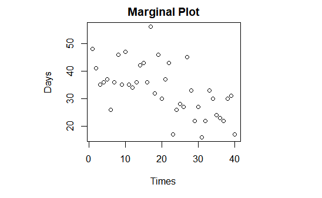

```r
stripchart(days,method="stack",offset=0.5,vertical=TRUE,axes=FALSE)
```

[output not shown]

## Histogram

- is a more compact summary of data than a stem-and-leaf plot.
- better suited for larger data set, 75 to 100 or more observations

### Process

- Divide the range of the data into intervals– **class intervals, cells,** or **bins** *(determine upper and lower boundary of each bin)*
  - the number of bins depends on the number of observations and the amount of scatter or dispersion in the data. In general, between 5 to 20 bins is statisfactory in most cases.
  - Number of bins should increase with $n$, number of observations
  - approximately equal to the square root of the number observations often works well.
  - **Sturger’s rule**, $h=1+\log_2n$ where $n$ is the sample size.
- determine axes of the histogram
  - Use horizontal axis to represent the measurement scale for the data
  - Use the vertical scale to represent the counts, or **frequencies**
  - when the frequencies in each bin are divided by the total number of observations $(n)$, it is called **relative frequencies**
- draw rectangles over each bin so that the height of each rectangle is proportional to the frequenciy, or relative frequency

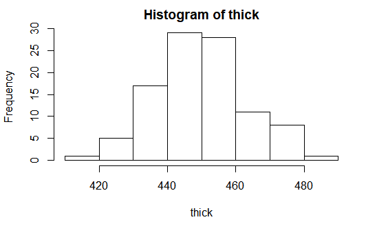

```r
thick <- c(438,413,444,468,445,472,474,454,455,449,450,450,450,459,466,470,457,441,450,445,487,430,446,450,456,433,455,459,423,455,451,437,444,453,434,454,448,435,432,441,452,465,466,473,471,464,478,446,459,464,441,444,458,454,437,443,465,435,444,457,444,471,471,458,459,449,462,460,445,437,461,453,452,438,445,435,454,428,454,434,432,431,455,447,454,435,425,449,449,452,471,458,445,463,423,451,440,442,441,439)
hist(thick)
```

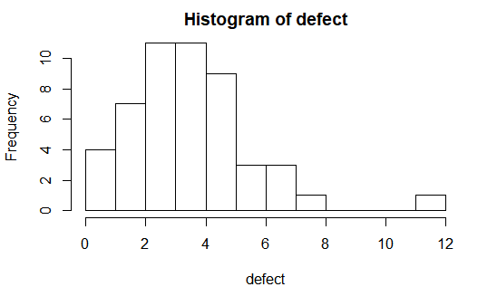

```r
defect <- c(6,1,5,7,8,6,0,2,4,2,5,2,4,4,1,4,1,7,2,3,4,3,3,3,6,3,2,3,4,5,5,2,3,4,4,4,2,3,5,7,5,4,5,5,4,5,3,3,3,12)
hist(defect,12)
```

## Numerical Summary of Data

- Numerical measures of central tendency and scatter.
- suppose that $x_1, x_2, ...,x_n$ are observations

### Sample Average

$$\bar{x}=\frac{x_1+x_2+...+x_n}{n}=\frac{\sum_{i=1}^{n}x_i}{n}$$
- arithmetic mean of the $n$ observations

```r
mean(thick)
```

```
[1] 450.01
```

### Sample Variance

$$s^2=\frac{\sum_{i=1}^{n}(x_i-\bar{x})^2}{n-1}$$
- measure variability in the sample data - if there is no variability in the sample, each observation $x_i=\bar{x}$ and the sample variance $S^2=0$

```r
var(thick)
```

```
[1] 180.2928
```

### Sample Standard Deviation

$$s=\sqrt{\frac{\sum_{i=1}^n(x_i-\bar{x})^2}{n-1}}$$

```r
sd(thick)
```

```
[1] 13.42732
```

## Box Plot (Box Whisker Plot)

- graphical display for data that simultaneously displays:
  - central tendency
  - spread of variability
  - departure from symmetry
  - identification of outliers
- displays the three quartiles (Q1, Q2, and Q3), the minimum, and the maximum of the data on a rectangle box (vertical or horizontal)

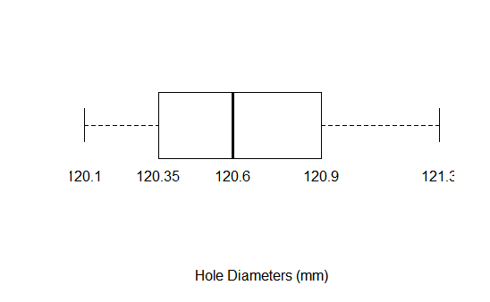

```r
diameter <- c(120.5,120.9,120.3,121.3,120.4,120.2,120.1,120.5,120.7,121.1,120.9,120.8)
bp <- boxplot(diameter, horizontal=TRUE, xlab="Hole Diameters (mm)", border=TRUE, frame=FALSE,axes=FALSE)
leg <- as.character(bp$stats)
text(x=bp$stats,y=0.7,labels=leg)
```

## Probablity Distribution

- A mathematical model that relates the value of the variable with the probability of occurence that value in the population.
- There are two types of probability distribution:

### Continous Distributions

- when the variable being measured is on a continous scale, its probability distribution is called a *continous distribution*
- the appearance of the continous distribution is a curve with area under the curve equal to probability
- the probability that $x$ lies in the interval from $a$ to $b$ is written as
  $$P\{a\le{x}\le{b}\}=\int_a^b f(x)dx$$

### Discrete Distributions

- when the parameter being measured can only take on certain values, its probability distribution is called a *discrete distribution*
- the appearance of a discrete distribution is a series of vertical spikes with the height of each spike proportional to the probability.
- the distribution can be described as:
  $$P\{x=x_i\}=p(x_i)$$

#### Central Tendency

- The *mean* $\mu$ of a probability distribution is a measure of the **central tendency** in the distribution.
- the mean is defined as
  $$\begin{equation}
  \mu =
  \begin{cases}
  \int_{-\infty}^{\infty}xf(x)dx,x \text{ continuous}\\
  \sum_{i=1}^{\infty}x_i p(x_i),x \text{ discrete}
  \end{cases}
  \end{equation}$$
- the mean of a discrete random variable with exactly $N$ equally likely values can be simplified to

$$\mu=\frac{\sum_{i=1}^{N}x_i}{N}$$

- the scatter, spread, or variability in a distribution is expressed by the **variance** $\sigma^2$
- the variance is defined as:

$$\begin{equation}
\sigma^2=
\begin{cases}
\int_{-\infty}^{\infty}(x-\mu)^2f(x)dx,x \text{ continuous}\\
\sum_{i=1}^{\infty}(x_i-\mu)^2p(x_i),x \text{ discrete}
\end{cases}
\end{equation}$$

- the variance of $N$ random variables with equally likely values becomes

$$\sigma^2=\frac{\sum_{i=1}^{N}(x_i-\mu)^2}{N}$$

- It is customary to work with square root of variance, called the **standard deviation** $\sigma$
  $$\sqrt{\sigma^2}=\sqrt{\frac{\sum_{i=1}^{N}(x_i-\mu)^2}{N}}$$
- standard deviation is the measure of spread in the population

# 2. Important Discrete Distributions

## The Hypergeometric Distribution

### Definition

- hypergeometric random variable $x$
  - within a finite population consisting of $N$ items,
  - $D(D\le N)$ all into a class of interes
  - a random sample of $n$ items is selected from the population *without replacement*, $x$ is the number observed that belongs to the class of interst

#### probability distribution is defined as:

$$p(x)=\frac{
\left(
\begin{matrix}
D\\
x
\end{matrix}
\right)
\left(
\begin{matrix}
N-D\\
n-x
\end{matrix}
\right)
}
{
\left(
\begin{matrix}
N\\
n
\end{matrix}
\right)
}
x=0,1,2,...,\text{min}(n,D)$$

- $D$: number of defective items in the population
- $x$: number of defective items in the sample
- $N$: number of items in the population
- $n$: number of items being sampled without replacement

#### Mean

$$\mu=\frac{nD}{N}$$

#### Variance

$$\sigma^2=\frac{nD}{N}(1-\frac{D}{N})
(\frac{N-n}{N-1})$$

#### Number of **Combinations of $a$ Items Taken $b$ at a Time**

$$\left(
\begin{matrix}
a\\
b
\end{matrix}
\right)=\frac{a!}{b!(a-b)!}$$
- the **hypergeometric distribution** is the appropriate probability model for selecting a *random sample* of $n$ items *without replacement* from a lot of $N$ items of which $D$ are non conforming (defective) - $x$ usually represents the number of nonconforming items found in the sample

```r
# Displaying Cumulative Distribution Function of Hypergeometric Distribution
# x=0,1,2,3,4,5,6,7,8,9,10
# D=5; nonconforming
# lot size, N =5+95=100, conforming=100-5=95
# n=10; sampling size
# p(X $\le$ x)
library(gridExtra)
library(grid)
drawn <- c(0:10)
cumulative.probability <- phyper(drawn,5,95,10)
# probability of 0, 1, 2, 3,...,10 nonconformative items found in the sample.
hyper <- cbind(drawn,cumulative.probability)
grid.newpage()
g <- grid.table(hyper)
```

[output not shown]

## The Binomial Distribution

### Bernoulli Trials

- a process consists of a sequence of $n$ independent trials (the outcome of each trial does not depend in any way of the outcome of previous trials)
- the outcome of each trial is either a *success* or a *failure*

### Definition

- the probability of “success” on any trial, $p$ is constant
- the number of “successes” $x$ in $n$ Bernoulli trial has the **bionomial distribution** with parameters $n \ge 0$ and $0<p<1$ defined as:

$$p(x)=\left(\begin{array} \\n \\x\end{array}\right)p^x(1-p)^{n-x} \hspace{1cm} x=0,1,...,n$$

- The mean of the binomial distribution is
  $$\mu=np$$
- The variance of the binomial distribution is

$$\sigma^2=np(1-p)$$
- the binomial distribution is the appropriate probability model for sampling from an infinitely large population where

$p$ represents the fraction of defective item in poplulation $x$ represents the number of nonconforming item found in a random sample of $n$ items

```r
library(grid)
library(gridExtra)
drawn=c(0:10)
pd <- dbinom(drawn,15,0.1)
bd <- cbind(drawn,pd)
grid.newpage()
grid.table(bd)
```

[output not shown]

- for a fixed $n$, the binomial distribution becomes more symmetric as $p$ increases from $0$ to $0.5$ or decreases from $1$ to $0.5$
- for a fixed $p$, the distriubtion becomes more symmetric as $n$ increases

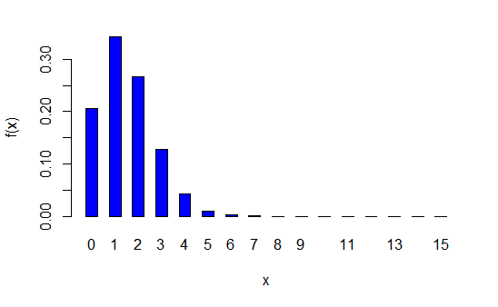

```r
n=c(0:15)
bd0.1 <- dbinom(n,15,0.1)
bd0.5 <- dbinom(n,15,0.5)
bd0.9 <- dbinom(n,15,0.9)
barplot(bd0.1,n,col="blue",xlab="x",ylab="f(x)",beside=TRUE,axes=TRUE,width=15,space=1)
```

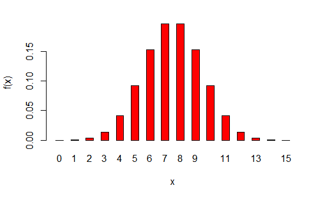

```r
barplot(bd0.5,n,col="red",xlab="x",ylab="f(x)",beside=TRUE,axes=TRUE,width=15,space=1)
```

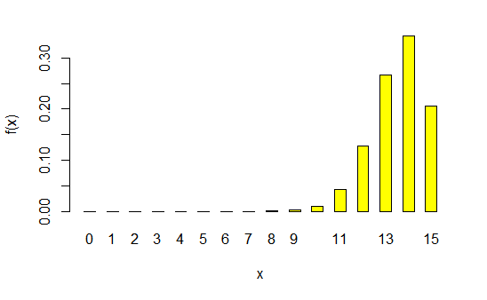

```r
barplot(bd0.9,n,col="yellow",xlab="x",ylab="f(x)",beside=TRUE,axes=TRUE,width=15,space=1)
```

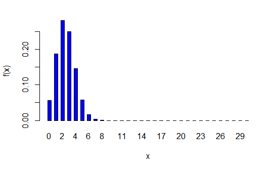

```r
n <- c(0:30)
bd1 <- dbinom(n,10,0.25)
bd2 <- dbinom(n,20,0.25)
bd3 <- dbinom(n,40,0.25)
barplot(bd1,n,col="blue",xlab="x",ylab="f(x)",beside=TRUE,axes=TRUE,width=15,space=1)
```

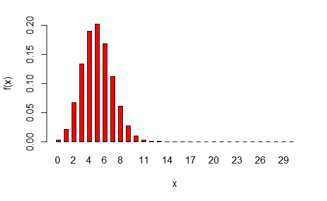

```r
barplot(bd2,n,col="red",xlab="x",ylab="f(x)",beside=TRUE,axes=TRUE,width=15,space=1)
```

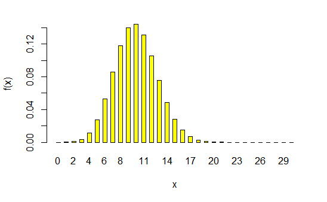

```r
barplot(bd3,n,col="yellow",xlab="x",ylab="f(x)",beside=TRUE,axes=TRUE,width=15,space=1)
```

## The Poisson Distribution

## The Pascal and Related Distributions

# 3. Important Continuous Distributions

## The Normal Distribution

## The Lognormal Distribution

## The Exponential Distribution

## The Gamma Distribution

## The Weibull Distribution

# 4. Probability Plots

## Normal Probability Plot

## Other Probability Plots

# 5. Some Useful Approximation

## The Binomial Approximation to the Hypergeometric

## The Poisson Approximation to the Binomial

## The Normal Approximation to the Binomial